Software Product Mastering / Das unsichtbare Biest / Das "Was" und das "Wie" / Stacey Matrix / Cynefin-Modell / Softwarekomplexität seit 1980 / Conways law / Zusammenfassung Theorie

# Software-Projekte und Software-Produkte

[output not shown]

**Softwareprojekt**

- Zeitlich begrenzt, hat festen Start und Abschluss
- Zielgerichtet auf ein spezifisches Ergebnis (z. B. Feature oder Version)
- Einmalig, oft nicht wiederholbar in dieser Form
- Budget und Ressourcen festgelegt
- Projektmanagement-Methoden (z. B. Agile, Wasserfall)
- Endet mit Lieferung eines abgeschlossenen Ergebnisses

**Softwareprodukt**

- Langfristiger Lebenszyklus, kontinuierliche Entwicklung
- Ziel: dauerhafter Nutzen und Wert für Kunden
- Regelmäßige Updates und Wartung (Versionierung)
- Kundenzentriert, orientiert an Feedback und Marktbedürfnissen
- Produktmanagement und strategische Planung
- Monetarisierungsmodell, um Einnahmen zu generieren

**Hauptunterschiede**

- Projekte: zeitlich begrenzt, spezifisches Ziel, endet mit Fertigstellung
- Produkte: langfristig, kontinuierliche Verbesserung, Kunden- und Marktfokus

**Nochmal zum Nachlesen...**

Softwareprojekte und Softwareprodukte sind zwei eng verwandte, aber unterschiedliche Konzepte in der Softwareentwicklung, die sich in Zielen, zeitlichem Rahmen, Herangehensweise und Resultaten unterscheiden. Hier ist eine detaillierte Erklärung der beiden Begriffe und der Unterschiede:

### 1. Softwareprojekte

Ein **Softwareprojekt** ist ein zeitlich begrenztes Vorhaben zur Entwicklung oder Anpassung von Software mit einem klaren Ziel und definierten Anforderungen. Es kann Teil eines größeren Programms oder Produkts sein, ist jedoch als eigenständige Initiative organisiert, die in der Regel durch Projektmanagement gesteuert wird.

**Merkmale eines Softwareprojekts**:

- **Zielorientierung**: Jedes Projekt hat ein spezifisches Ziel, wie z. B. die Entwicklung eines neuen Features, die Einführung einer Anwendung oder die Anpassung einer bestehenden Lösung.
- **Zeitliche Begrenzung**: Projekte haben feste Start- und Endtermine und werden in der Regel in Phasen organisiert (Initiierung, Planung, Durchführung, Abschluss).
- **Einzigartigkeit**: Ein Softwareprojekt wird meist nur einmal in dieser spezifischen Form durchgeführt, da das Ziel, die Anforderungen und die Bedingungen für jedes Projekt unterschiedlich sind.
- **Budget und Ressourcen**: Projekte haben ein zugewiesenes Budget und spezifische Ressourcen (Mitarbeiter, Werkzeuge), die für die Erreichung des Ziels vorgesehen sind.
- **Projektmanagement-Methoden**: Für die Durchführung und Steuerung eines Projekts werden oft Methoden wie Agile, Scrum, Kanban oder klassisches Wasserfall-Projektmanagement verwendet, je nach Komplexität und Anforderungen.
- **Endergebnis**: Das Endergebnis eines Projekts ist eine konkrete, abgeschlossene Version eines Softwareelements oder einer gesamten Anwendung, das spezifische Anforderungen erfüllt.

### 2. Softwareprodukte

Ein **Softwareprodukt** hingegen ist eine Softwareanwendung oder -lösung, die für einen bestimmten Markt oder eine bestimmte Zielgruppe entwickelt wird und über einen längeren Zeitraum gepflegt, erweitert und aktualisiert wird. Der Fokus liegt hier auf der Bereitstellung von langfristigem Wert für Benutzer oder Kunden.

**Merkmale eines Softwareprodukts**:

- **Langfristiger Lebenszyklus**: Softwareprodukte werden entwickelt, um langfristig am Markt verfügbar zu sein und kontinuierlich Nutzen für die Anwender zu stiften.
- **Versionierung und Wartung**: Produkte werden regelmäßig aktualisiert, um Fehler zu beheben, neue Funktionen hinzuzufügen und sich an Marktanforderungen anzupassen. Dies erfordert kontinuierliche Wartung, Verbesserung und Support.
- **Wertorientierung**: Ein Softwareprodukt zielt darauf ab, dauerhaften Nutzen zu bieten, indem es für spezifische Probleme der Zielgruppe Lösungen bereitstellt. Der Wert kann wirtschaftlicher oder funktionaler Natur sein.
- **Kundenzentrierung**: Im Mittelpunkt der Produktentwicklung stehen die Bedürfnisse der Kunden und Anwender. Die Entwicklung neuer Funktionen oder Verbesserungen orientiert sich am Feedback der Nutzer und an Marktentwicklungen.
- **Produktmanagement**: Produkte haben in der Regel ein dediziertes Produktmanagement-Team, das die Strategie und den Roadmap-Plan für das Produkt definiert, um den langfristigen Erfolg sicherzustellen.
- **Revenue und Marktausrichtung**: Viele Softwareprodukte haben ein Geschäftsmodell (z. B. Abonnement, Lizenzierung), um Umsatz zu generieren, und müssen sich gegen Wettbewerber im Markt behaupten.

### 3. Unterschied zwischen Softwareprojekten und Softwareprodukten

| Faktor | Softwareprojekt | Softwareprodukt |
| --- | --- | --- |
| **Ziel** | Erreichen eines spezifischen Ziels, z. B. ein Feature oder eine Version | Bereitstellung langfristigen Nutzens und Wertschöpfung für Kunden |
| **Zeithorizont** | Zeitlich begrenzt, mit festem Start und Abschluss | Unbefristet, kontinuierliche Weiterentwicklung |
| **Kundenfokus** | Fokus auf das Projektziel, oft unabhängig von langfristigen Kundenbedürfnissen | Kunden- und marktorientiert, regelmäßiges Feedback fließt ein |
| **Management** | Wird durch Projektmanagement-Methoden gesteuert | Durch Produktmanagement, das Markt und Nutzerbedürfnisse im Blick hat |
| **Finanzierung** | Budget wird projektbezogen geplant und zugewiesen | Einnahmen durch verschiedene Monetarisierungsmodelle |
| **Ergebnis** | Ein konkretes und meist abgeschlossenes Produkt (z. B. eine Version) | Ein fortlaufend verfügbares Produkt, das regelmäßig aktualisiert wird |

### Zusammengefasst:

Der wesentliche Unterschied liegt in der **zeitlichen Begrenzung und Zielsetzung**: Während ein **Softwareprojekt** ein abgeschlossenes Vorhaben mit klarem Ziel ist, dient ein **Softwareprodukt** der fortlaufenden Bereitstellung von Nutzen für den Markt. Ein Projekt endet mit der Erfüllung seines spezifischen Ziels, wohingegen ein Produkt in einem permanenten Prozess der Verbesserung und Anpassung bleibt, solange es auf dem Markt existiert.

## Unterschiede spielerisch kennenlernen

Hier ist ein Codebeispiel, das den Unterschied zwischen einem Softwareprojekt und einem Softwareprodukt spielerisch verdeutlicht. Die Idee ist, zwei einfache Aufgaben zu simulieren: eine, die wie ein abgeschlossenes Projekt funktioniert (mit einer festen Zielvorgabe), und eine, die einem Produkt mit kontinuierlicher Verbesserung ähnelt (mit einem Feedbackprozess).

```
----Simulating Software Project----
Software Project Simulation: Develop feature
Project Progress: 30%
Project Progress: 43%
Project Progress: 53%
Project Progress: 71%
Project Progress: 88%
Project Progress: 100%

Project Completed! Feature 'Login System' is fully developed.

----Simulating Software Product----
Software Product Simulation: Continuous Improvement

Version 1.0 Released
User Feedback: 3/10
Product updated to version 1.1

Version 1.1 Released
User Feedback: 2/10
Product updated to version 1.2

Version 1.2000000000000002 Released
User Feedback: 9/10
Product updated to version 1.3

Version 1.3000000000000003 Released
User Feedback: 2/10
Product updated to version 1.4

Version 1.4000000000000004 Released
User Feedback: 10/10
Product updated to version 1.5
```

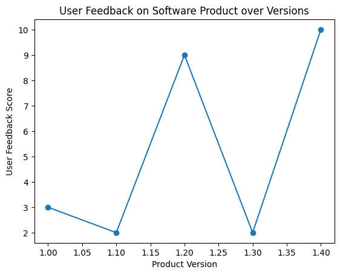

```
Product continues to evolve based on feedback and improvements.
```

```python
# Import necessary libraries
import time
import random
import matplotlib.pyplot as plt

# Set random seed for reproducibility
random.seed(42)

# Function simulating a software project with a clear end goal
def software_project(target_feature):
    print("Software Project Simulation: Develop feature")
    completed = False
    progress = 0
    goal = 100  # represents 100% completion

    # Simulate progress towards a fixed goal
    while not completed:
        progress += random.randint(10, 30)  # Simulate work chunks
        time.sleep(0.5)

        # Cap progress at the goal and complete the project
        if progress >= goal:
            progress = goal
            completed = True
        print(f"Project Progress: {progress}%")

    print(f"\nProject Completed! Feature '{target_feature}' is fully developed.")

# Function simulating a software product with continuous updates and improvements
def software_product(initial_version, updates=5):
    print("Software Product Simulation: Continuous Improvement")
    version = initial_version
    user_feedback_scores = []
    version_scores = []

    # Simulate continuous improvement process
    for i in range(updates):
        print(f"\nVersion {version} Released")

        # Get random feedback from users (simulating feedback loop)
        feedback = random.randint(1, 10)
        user_feedback_scores.append(feedback)
        version_scores.append(version)
        print(f"User Feedback: {feedback}/10")

        # Update the version and simulate improvement
        version += 0.1  # Increment version
        print(f"Product updated to version {version:.1f}")
        time.sleep(0.5)

    # Plot feedback over versions
    plt.plot(version_scores, user_feedback_scores, marker='o')
    plt.title("User Feedback on Software Product over Versions")
    plt.xlabel("Product Version")
    plt.ylabel("User Feedback Score")
    plt.show()
    print("Product continues to evolve based on feedback and improvements.\n")

# Run simulations
print("----Simulating Software Project----")
software_project("Login System")

print("\n----Simulating Software Product----")
software_product(1.0)
```

### Erläuterung des Codes

1. **Softwareprojekt**: Ein festes Ziel (z. B. "Login System") wird erreicht, indem die Simulation Fortschrittsschritte ausführt, bis 100% erreicht sind. Sobald das Ziel erreicht ist, wird das Projekt als abgeschlossen betrachtet.
2. **Softwareprodukt**: In dieser Simulation wird eine anfängliche Produktversion kontinuierlich aktualisiert, basierend auf zufälligem Benutzerfeedback. Die Version wird iterativ verbessert, und das Feedback wird auf einem Diagramm dargestellt, um den fortlaufenden Charakter eines Produkts zu verdeutlichen.